Agrupamentos dos Estabelecimentos de Internação registrados no TABNET, São Paulo, triênio 2020 a 2022, verificando se a saturação de oxigênio está abaixo de 95% em pacientes com Síndrome Respiratória Aguda Grave **Prevent Senior** *Sistema de Gestão da Qualidade* Última atualização em 13 / 10 / 2022 às 17:06 horas.

Abstract

Este relatório agrupa os estabelecimentos de internação para covid-19 (Síndrome Respiratória Aguda Grave) registrados no TABNET, Secretaria Municipal de Saúde de São Paulo, em grupos homogêneos em função do grau de similaridade entre si

# Introdução

Este relatório tem por objetivo agrupar os estabelecimentos de internação registrados na Secretaria Municipal de Sáude de São Paulo em relação à saturação de oxigênio dos pacientes no que diz respeito à Covid-19 com diagnóstico de Síndrome Respiratória Aguda Grave (SRAG), nos anos de 2020 a 2022.

A ideia principal é agrupar os objetos (estabelecimentos de internação) com base nas características das variáveis (saturação de oxigênio < 95%).

O agrupamento destes estabelecimentos de internação com estas variáveis (*features*) foi processado pela técnica de interdependência **análise de clusters**.

# Análise de *clusters*

A análise de *clusters* agrupa os objetos (estabelecimentos de internação) com base em suas próprias características (saturação de oxigênio), buscando uma estrutura natural para estes objetos.

O objetivo da técnica é segmentar as observações em grupos homogêneos internamente (estabelecimentos de internação com medidas de saturação de oxigênio) e heterogêneos entre si e mutuamente exclusivos.

Esta análise identifica objetos semelhantes (estabelecimentos de internação) com base em suas semelhanças (*features*). Ou seja, a técnica identifica grupos de objetos (estabelecimentos de internação) de modo que cada objeto se assemelha aos demais do agrupamento.

Na análise de *clusters*, diferentemente de outras técnicas de análises multivariadas, as *features* de agrupamento (variáveis estatísticas) são selecionadas pelo pesquisador (não são selecionadas empiricamente).

É uma técnica descritiva, com fortes propriedades matemáticas e que não é apropriada para realizar inferências de características da população a partir de amostras.

## Análise das variáveis e dos objetos para formar os *clusters*

A seleção das *features* deve refletir a estrutura inerente que formam os grupos. Cabe ao pesquisador selecionar aquelas que se alinham ao objetivo da pesquisa. Convém minimizar o uso de variáveis não representativas e atentar para a presença de multicolinariedade (pode interferir na ponderação das medidas de similaridade).

Esta técnica é altamente sensível à inclusão de variáveis com comportamentos atípicos (*outliers*). Convém verificar a existência de *outliers* e considerar mecanismos para minimizar seus impactos.

# Base de dados de 2020

A base de dados para esta análise está disponível no aplicativo [TABNET](https://www.prefeitura.sp.gov.br/cidade/secretarias/saude/tabnet/index.php?p=296871) desenvolvido pelo DATASUS.

A Secretaria Municipal de Sáude de São Paulo disponibiliza o [TABNET](https://www.prefeitura.sp.gov.br/cidade/secretarias/saude/tabnet/index.php?p=296871) para o acesso às bases de dados de população e dos sistemas de informações do SUS.

## Carregando a base de dados

Esta análise traz o número de casos (**contéudo**) por estabelecimento de internação (**linha**) e por saturação de oxigênio (**coluna**) da página [COVID 19 Síndrome Respiratória Aguda Grave (SGAG)](http://tabnet.saude.prefeitura.sp.gov.br/cgi/tabcgi.exe?secretarias/saude/TABNET/RSRAG/sragh.def).

## Visão geral dos dados

```
## Rows: 151
## Columns: 7
## $ estab_internacao <chr> "2077531 A C CAMARGO CANCER CENTER", "6430120 BP MIRA…
## $ sim              <int> 100, 53, 231, 164, 606, 130, 2463, 520, 110, 511, 174…
## $ nao              <int> 212, 68, 69, 46, 226, 142, 506, 61, 17, 823, 742, 110…
## $ ign              <int> 14, 2, 30, 74, 153, 2, 568, 47, 267, 31, 28, 3, 4, 8,…
## $ total            <int> 326, 123, 330, 284, 985, 274, 3537, 628, 394, 1365, 9…
## $ taxa_sim         <dbl> 0.30674847, 0.43089431, 0.70000000, 0.57746479, 0.615…
## $ taxa_nao         <dbl> 0.65030675, 0.55284553, 0.20909091, 0.16197183, 0.229…
```

## Entendimento da base de dados

```
##   rows columns discrete_columns continuous_columns all_missing_columns
## 1  151       7                1                  6                   0
##   total_missing_values complete_rows total_observations memory_usage
## 1                    0           151               1057        23088
```

[output not shown]

## Tipos de valores e ocorrência de valores ausentes.

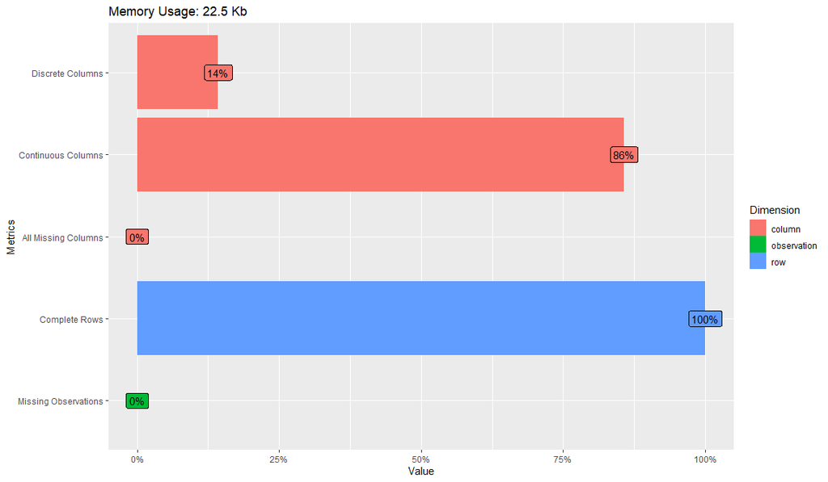

## Correlação entre as variáveis

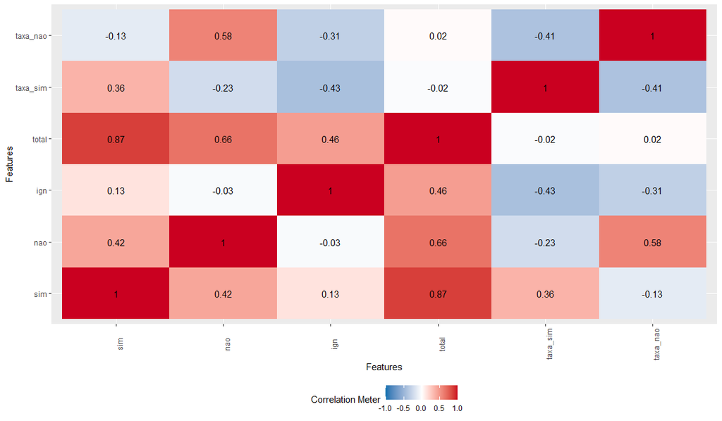

## Distribuição das variáveis quantitativas.

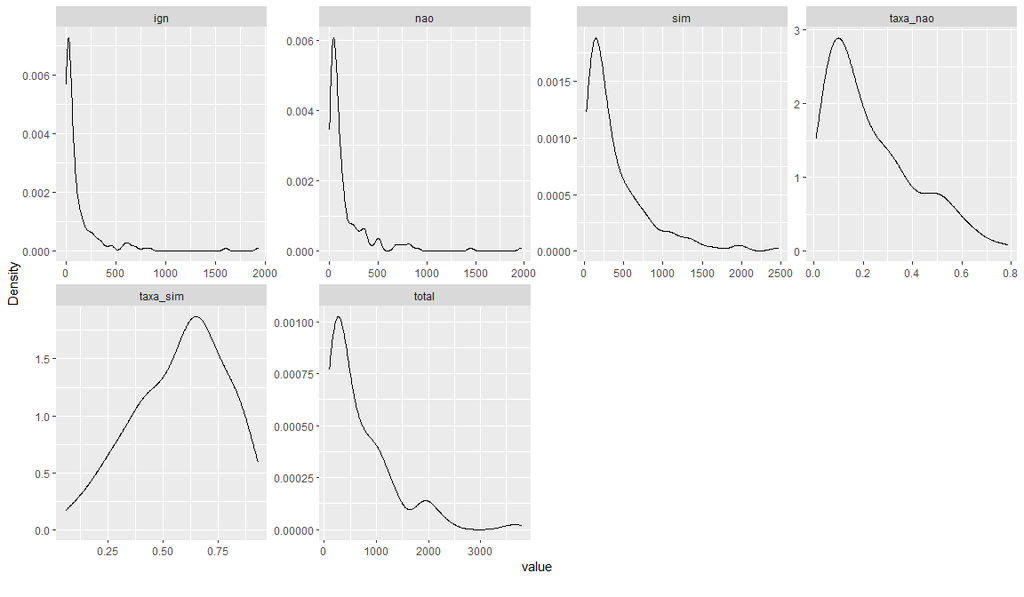

# Preparação dos dados

Para fins desta análise foram considerados todos os estabelecimentos de internação com um número de casos igual ou maior a 100 casos de internação/ano. Foram selecionados 151 estabelecimentos de internação com esta característica.

```
##   sim nao total  taxa_sim  taxa_nao
## 1 100 212   326 0.3067485 0.6503067
## 2  53  68   123 0.4308943 0.5528455
## 3 231  69   330 0.7000000 0.2090909
## 4 164  46   284 0.5774648 0.1619718
## 5 606 226   985 0.6152284 0.2294416
## 6 130 142   274 0.4744526 0.5182482
```

## Resumo sumário das variáveis

A próxima saída trás os valores de seis medidas (em ordem crescente):

- Menor valor (*Min*): o menor valor da variável registrada em algum estabelecimento de internação.
- Primeiro quartil Q<sub>1</sub> (*1st Qu*): 25% os estabelecimentos de internação registraram um valor da variável abaixo desse valor.
- Mediana Q<sub>2</sub> (*median*): 50% os estabelecimentos de internação registraram um valor da variável abaixo desse valor.
- Média (*mean*): média aritmética dos valores da variável registrada pelos estabelecimentos de internação.
- Terceiro quartil Q<sub>3</sub> (*3rd Qu*): 75% os estabelecimentos de internação registraram um valor da variável abaixo desse valor.
- Maior valor (*Max*): o maior valor da variável registrada em algum estabelecimento de internação.

```
##       sim              nao             total           taxa_sim
##  Min.   :  30.0   Min.   :   1.0   Min.   : 100.0   Min.   :0.05948
##  1st Qu.: 131.0   1st Qu.:  39.0   1st Qu.: 250.0   1st Qu.:0.42786
##  Median : 236.0   Median :  71.0   Median : 465.0   Median :0.61238
##  Mean   : 404.3   Mean   : 163.9   Mean   : 702.5   Mean   :0.58020
##  3rd Qu.: 527.0   3rd Qu.: 159.5   3rd Qu.: 984.5   3rd Qu.:0.73178
##  Max.   :2463.0   Max.   :1968.0   Max.   :3780.0   Max.   :0.93165
##     taxa_nao
##  Min.   :0.008621
##  1st Qu.:0.085011
##  Median :0.161972
##  Mean   :0.229724
##  3rd Qu.:0.330342
##  Max.   :0.786017
```

À guisa de exemplo, considere a *feature* **taxa de sim**:

Observe que 25% dos estabelecimentos de internação registraram uma taxa de saturação por SRAG igual ou maior a 73,17%.

Esta informação pode ser visualizada no seguinte *boxplot*.

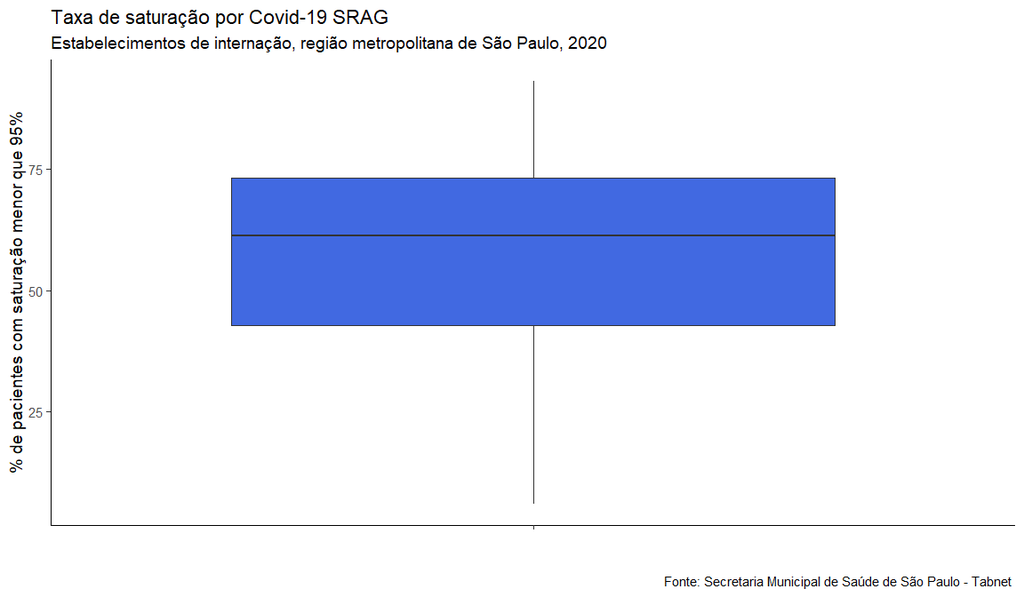

## Padronização dos dados

A utilização de variáveis com medidas e ou escalas diferentes podem distorcer a estrutura do *cluster*. Variáveis com maior dispersão têm maior peso para o cálculo das medidas de distância do que as demais.

A padronização dos dados faz com que seja atribuído o mesmo peso para cada variável. Neste estudo foi utilizada a transformação de cada variável em escore padrão (*Z score*). O método Z score padroniza cada variável de modo a apresentar uma média zero(0) e desvio padrão um (1):

$$Z = \frac{(x - média)}{desvio \ padrão}$$

```
##             sim         nao      total    taxa_sim     taxa_nao
## [1,] -0.7224378  0.18714374 -0.5794786 -1.31395198  2.356780929
## [2,] -0.8340065 -0.37343671 -0.8918897 -0.71742722  1.810646896
## [3,] -0.4114696 -0.36954379 -0.5733227  0.57563426 -0.115617690
## [4,] -0.5705144 -0.45908094 -0.6441154 -0.01315136 -0.379654321
## [5,]  0.4787064  0.24164462  0.4347032  0.16830413 -0.001580351
## [6,] -0.6512237 -0.08536064 -0.6595051 -0.50812845  1.616777046
```

# Modelagem estatística - Método *K-means*

O método *k-means* é um procedimento não hierárquico para agrupar indivíduos, cujo número inicial de *clusters* é definido pelo pesquisador.

O algoritmo para determinar a alocação das observações em cada conglomerado é denominado *nearest centroid sorting*. O *K-means* usa a distância euclidiana como critério de distância para formar os grupos.

## Determinação do número de *clusters*

O método *k-means* é um procedimento não hierárquico para agrupar indivíduos, cujo número inicial de *clusters* é definido pelo pesquisador.

A análise visual a partir de um gráfico de linhas de duas dimensões: os *K Clusters* (*Number of clusters k*) e a Soma dos Quadrados dos Erros de Predição (*Total Within Sum of Square - SSE*) sugere um número inicial de *clusters* para ser usado. O SSE resulta na variância e desvio padrão (inércia) dos dados de nossa base. Desta forma pode-se visualizar o valor de quão próximo os dados estão uns dos outros. Quanto menor for o número de *clusters*, maior será o valor dessa inércia.

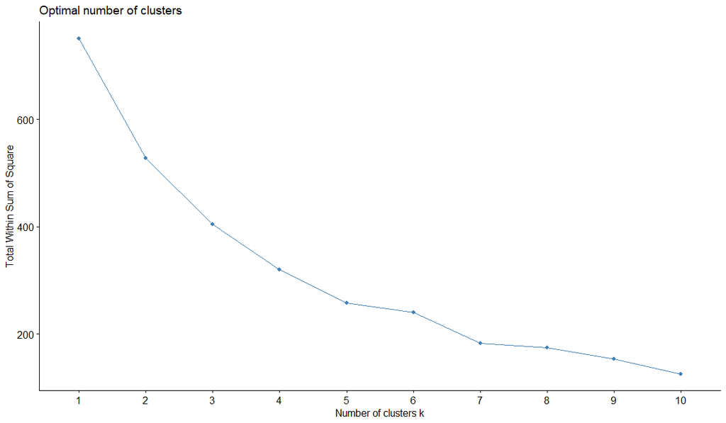

## Gráficos

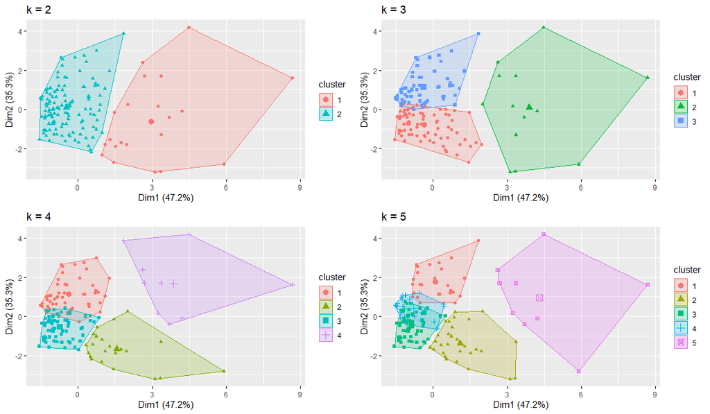

## Agrupar *cluster* e base

|  | estab_internacao | sim | nao | ign | total | taxa_sim | taxa_nao | saturacao.k5.cluster |
| --- | --- | --- | --- | --- | --- | --- | --- | --- |
| 7 | 2078015 HC DA FMUSP HOSPITAL DAS CLINICAS SAO PAULO | 2463 | 506 | 568 | 3537 | 0.6963528 | 0.1430591 | 5 |
| 10 | 2089238 HOSP ALVORADA | 511 | 823 | 31 | 1365 | 0.3743590 | 0.6029304 | 5 |
| 35 | 5718368 HOSP MUN M BOI MIRIM | 1365 | 821 | 43 | 2229 | 0.6123822 | 0.3683266 | 5 |
| 51 | 2688603 HOSP STA CATARINA | 330 | 1451 | 188 | 1969 | 0.1675978 | 0.7369223 | 5 |
| 54 | 2077477 HOSP STA MARCELINA SAO PAULO | 1655 | 1968 | 157 | 3780 | 0.4378307 | 0.5206349 | 5 |
| 61 | 2080575 HOSPITAL BP | 642 | 769 | 92 | 1503 | 0.4271457 | 0.5116434 | 5 |
| 69 | 0102083 HOSPITAL DE CAMPANHA COVID 19 SMS SP ANHEMBI P 38 | 1076 | 679 | 144 | 1899 | 0.5666140 | 0.3575566 | 5 |
| 83 | 2066092 HOSPITAL GERAL DE PEDREIRA | 1335 | 695 | 14 | 2044 | 0.6531311 | 0.3400196 | 5 |
| 121 | 2688565 HOSPITAL SAO CAMILO POMPEIA | 747 | 902 | 120 | 1769 | 0.4222725 | 0.5098926 | 5 |
| 9 | 2082314 HOSP ALBERT SABIN | 110 | 17 | 267 | 394 | 0.2791878 | 0.0431472 | 4 |
| 15 | 2058502 HOSP DO SERV PUB EST FCO MORATO DE OLIVEIRA SAO PAULO | 123 | 23 | 1922 | 2068 | 0.0594778 | 0.0111219 | 4 |
| 17 | 2077469 HOSP DOM ANTONIO DE ALVARENGA | 111 | 12 | 111 | 234 | 0.4743590 | 0.0512821 | 4 |
| 18 | 2089610 HOSP EDMUNDO VASCONCELOS | 111 | 76 | 198 | 385 | 0.2883117 | 0.1974026 | 4 |
| 31 | 2786680 HOSP MUN FERNANDO MAURO PIRES DA ROCHA | 209 | 17 | 173 | 399 | 0.5238095 | 0.0426065 | 4 |
| 33 | 2081970 HOSP MUN JABAQUARA ARTUR RIBEIRO DE SABOYA | 276 | 96 | 402 | 774 | 0.3565891 | 0.1240310 | 4 |
| 36 | 2079186 HOSP MUN MAT ESC DR MARIO DE MORAES A SILVA | 31 | 7 | 70 | 108 | 0.2870370 | 0.0648148 | 4 |
| 37 | 2075717 HOSP MUN MATERNIDADE PROFESSOR MARIO DEGNI | 47 | 28 | 39 | 114 | 0.4122807 | 0.2456140 | 4 |
| 38 | 2077639 HOSP MUN PROF DR WALDOMIRO DE PAULA | 521 | 53 | 618 | 1192 | 0.4370805 | 0.0444631 | 4 |
| 43 | 2089599 HOSP NSRA DE LOURDES | 155 | 79 | 1600 | 1834 | 0.0845147 | 0.0430752 | 4 |
| 49 | 2688611 HOSP SAO LUIZUNIDADE I | 61 | 45 | 158 | 264 | 0.2310606 | 0.1704545 | 4 |
| 56 | 7060165 HOSPITAL A C CAMARGO TAMANDARE | 39 | 28 | 33 | 100 | 0.3900000 | 0.2800000 | 4 |
| 58 | 2077507 HOSPITAL BANDEIRANTES | 527 | 45 | 597 | 1169 | 0.4508127 | 0.0384944 | 4 |
| 62 | 2081628 HOSPITAL CARLOS CHAGAS | 39 | 11 | 101 | 151 | 0.2582781 | 0.0728477 | 4 |
| 65 | 2080168 HOSPITAL DA CRIANCA | 30 | 11 | 322 | 363 | 0.0826446 | 0.0303030 | 4 |
| 67 | 3367371 HOSPITAL DA LUZ | 233 | 46 | 270 | 549 | 0.4244080 | 0.0837887 | 4 |
| 68 | 0113123 HOSPITAL DE CAMPANHA COVID 19 SMS SP ANHEMBI P 35 | 102 | 17 | 138 | 257 | 0.3968872 | 0.0661479 | 4 |
| 70 | 0102040 HOSPITAL DE CAMPANHA COVID 19 SMS SP PACAEMBU | 136 | 29 | 102 | 267 | 0.5093633 | 0.1086142 | 4 |
| 72 | 2081288 HOSPITAL DO CORACAO | 313 | 54 | 329 | 696 | 0.4497126 | 0.0775862 | 4 |
| 85 | 2688573 HOSPITAL GERAL DE VILA NOVA CACHOEIRINHA SAO PAULO | 230 | 14 | 785 | 1029 | 0.2235180 | 0.0136054 | 4 |
| 95 | 6283993 HOSPITAL LEFORTE | 105 | 110 | 456 | 671 | 0.1564829 | 0.1639344 | 4 |

[output cut: 121 more lines]

## Resumo do modelo

### Média Aritmética

| saturacao.k5$cluster | sim | nao | total | taxa_sim | taxa_nao |
| --- | --- | --- | --- | --- | --- |
| 1 | 206.1538 | 253.42308 | 501.2692 | 0.4138100 | 0.5100619 |
| 2 | 935.7586 | 168.13793 | 1272.2069 | 0.7358300 | 0.1394444 |
| 3 | 235.3860 | 57.80702 | 325.5789 | 0.7213284 | 0.1760426 |
| 4 | 167.2333 | 45.96667 | 583.4333 | 0.3346311 | 0.1085787 |
| 5 | 1124.8889 | 957.11111 | 2232.7778 | 0.4841873 | 0.4545539 |

### Desvio padrão

[output not shown]

### Coeficiente de Variação

| saturacao.k5$cluster | sim | nao | total | taxa_sim | taxa_nao |
| --- | --- | --- | --- | --- | --- |
| 1 | 67.47047 | 64.71018 | 60.21838 | 30.08701 | 20.11840 |
| 2 | 39.75696 | 73.37851 | 35.09097 | 15.35649 | 68.82359 |
| 3 | 54.72726 | 84.40370 | 52.60960 | 14.40790 | 54.01185 |
| 4 | 84.08829 | 85.99042 | 89.77117 | 38.40530 | 70.71970 |
| 5 | 59.30580 | 48.02589 | 38.17517 | 34.11772 | 38.05885 |

# Base de dados de 2021

A base de dados para esta análise está disponível no aplicativo [TABNET](https://www.prefeitura.sp.gov.br/cidade/secretarias/saude/tabnet/index.php?p=296871) desenvolvido pelo DATASUS.

A Secretaria Municipal de Sáude de São Paulo disponibiliza o [TABNET](https://www.prefeitura.sp.gov.br/cidade/secretarias/saude/tabnet/index.php?p=296871) para o acesso às bases de dados de população e dos sistemas de informações do SUS.

## Carregando a base de dados

Esta análise traz o número de casos (**contéudo**) por estabelecimento de internação (**linha**) e por saturação de oxigênio (**coluna**) da página [COVID 19 Síndrome Respiratória Aguda Grave (SGAG)](http://tabnet.saude.prefeitura.sp.gov.br/cgi/tabcgi.exe?secretarias/saude/TABNET/RSRAG/sragh.def).

## Visão geral dos dados

```
## Rows: 137
## Columns: 7
## $ estab_internacao <chr> "2077531 A C CAMARGO CANCER CENTER", "6430120 BP MIRA…
## $ sim              <int> 99, 65, 277, 575, 917, 117, 1620, 506, 108, 1398, 259…
## $ nao              <dbl> 73, 43, 10, 84, 268, 87, 22, 3, 0, 350, 356, 116, 47,…
## $ ign              <int> 11, 47, 26, 132, 238, 2, 344, 56, 323, 2, 9, 14, 3, 1…
## $ total            <int> 183, 155, 313, 791, 1423, 206, 1986, 565, 431, 1750, …
## $ taxa_sim         <dbl> 0.5409836, 0.4193548, 0.8849840, 0.7269279, 0.6444132…
## $ taxa_nao         <dbl> 0.398907104, 0.277419355, 0.031948882, 0.106194690, 0…
```

## Entendimento da base de dados

```
##   rows columns discrete_columns continuous_columns all_missing_columns
## 1  137       7                1                  6                   0
##   total_missing_values complete_rows total_observations memory_usage
## 1                    0           137                959        21696
```

[output not shown]

## Tipos de valores e ocorrência de valores ausentes.

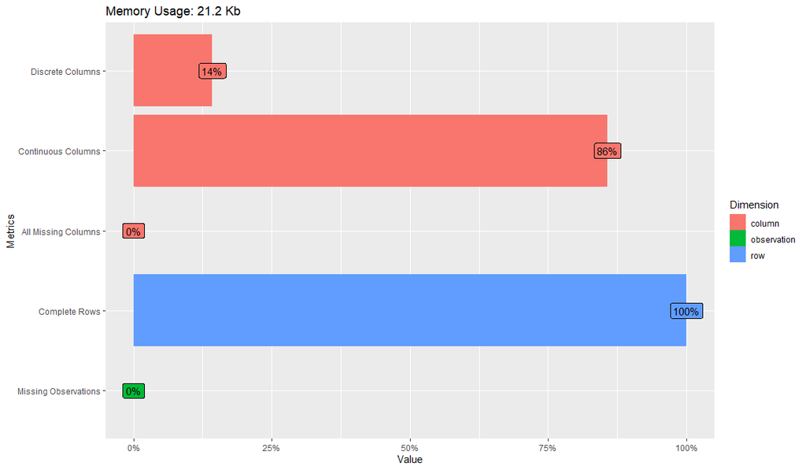

## Correlação entre as variáveis

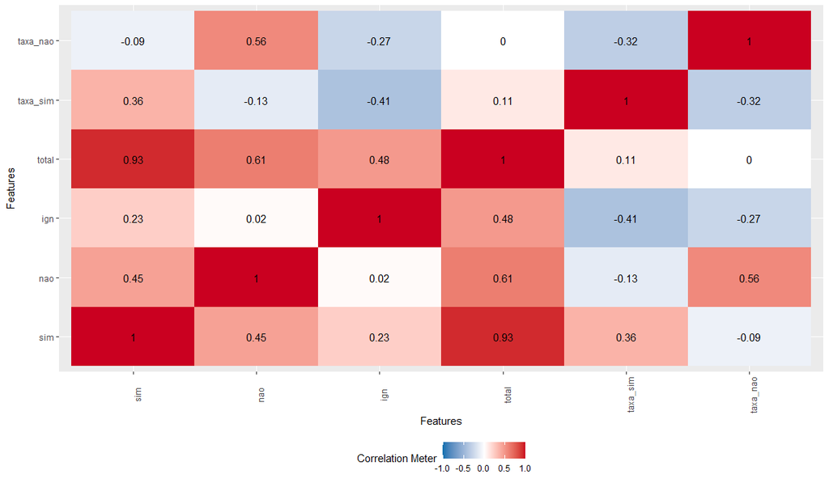

## Distribuição das variáveis quantitativas.

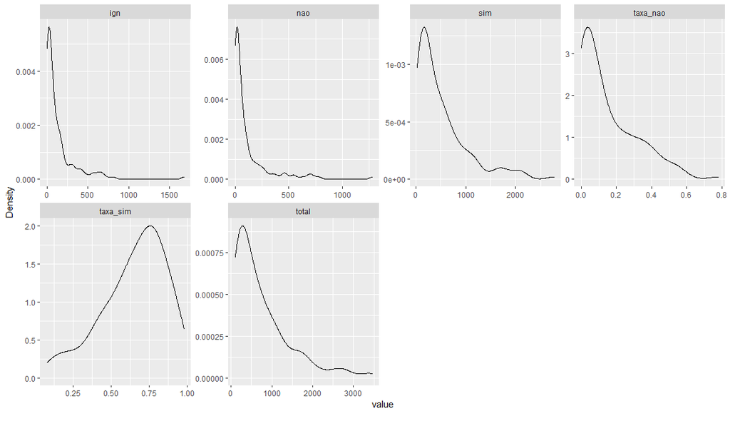

# Preparação dos dados

Para fins desta análise foram considerados todos os estabelecimentos de internação com um número de casos igual ou maior a 100 casos de internação/ano. Foram selecionados 137 estabelecimentos de internação com esta característica.

```
##   sim nao total  taxa_sim   taxa_nao
## 1  99  73   183 0.5409836 0.39890710
## 2  65  43   155 0.4193548 0.27741935
## 3 277  10   313 0.8849840 0.03194888
## 4 575  84   791 0.7269279 0.10619469
## 5 917 268  1423 0.6444132 0.18833450
## 6 117  87   206 0.5679612 0.42233010
```

## Resumo sumário das variáveis

A próxima saída trás os valores de seis medidas (em ordem crescente):

- Menor valor (*Min*): o menor valor da variável registrada em algum estabelecimento de internação.
- Primeiro quartil Q<sub>1</sub> (*1st Qu*): 25% os estabelecimentos de internação registraram um valor da variável abaixo desse valor.
- Mediana Q<sub>2</sub> (*median*): 50% os estabelecimentos de internação registraram um valor da variável abaixo desse valor.
- Média (*mean*): média aritmética dos valores da variável registrada pelos estabelecimentos de internação.
- Terceiro quartil Q<sub>3</sub> (*3rd Qu*): 75% os estabelecimentos de internação registraram um valor da variável abaixo desse valor.
- Maior valor (*Max*): o maior valor da variável registrada em algum estabelecimento de internação.

```
##       sim              nao             total           taxa_sim
##  Min.   :  24.0   Min.   :   0.0   Min.   : 102.0   Min.   :0.07783
##  1st Qu.: 126.0   1st Qu.:   8.0   1st Qu.: 218.0   1st Qu.:0.52174
##  Median : 304.0   Median :  39.0   Median : 543.0   Median :0.68924
##  Mean   : 504.6   Mean   : 112.9   Mean   : 753.7   Mean   :0.64852
##  3rd Qu.: 686.0   3rd Qu.: 118.0   3rd Qu.:1035.0   3rd Qu.:0.80000
##  Max.   :2775.0   Max.   :1280.0   Max.   :3465.0   Max.   :0.97857
##     taxa_nao
##  Min.   :0.00000
##  1st Qu.:0.01657
##  Median :0.08943
##  Mean   :0.14969
##  3rd Qu.:0.24127
##  Max.   :0.77992
```

À guisa de exemplo, considere a *feature* **taxa de sim**:

Observe que 25% dos estabelecimentos de internação registraram uma taxa de saturação por SRAG igual ou maior a 80,00%.

Esta informação pode ser visualizada no seguinte *boxplot*.

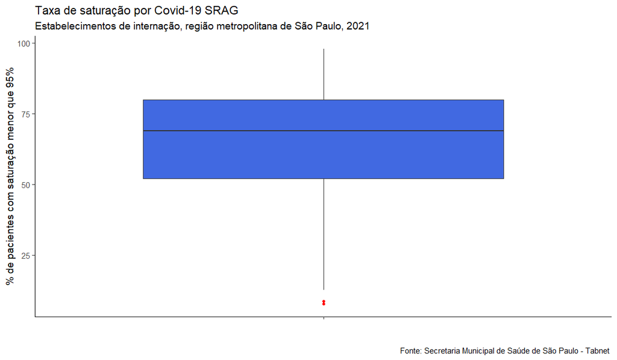

## Padronização dos dados

A utilização de variáveis com medidas e ou escalas diferentes podem distorcer a estrutura do *cluster*. Variáveis com maior dispersão têm maior peso para o cálculo das medidas de distância do que as demais.

A padronização dos dados faz com que seja atribuído o mesmo peso para cada variável. Neste estudo foi utilizada a transformação de cada variável em escore padrão (*Z score*). O método Z score padroniza cada variável de modo a apresentar uma média zero(0) e desvio padrão um (1):

$$Z = \frac{(x - média)}{desvio \ padrão}$$

```
##             sim        nao       total    taxa_sim   taxa_nao
## [1,] -0.7727256 -0.2077093 -0.80452395 -0.50639577  1.5358667
## [2,] -0.8374961 -0.3637761 -0.84399489 -1.07917101  0.7871634
## [3,] -0.4336335 -0.5354495 -0.62126602  1.11357398 -0.7256193
## [4,]  0.1340600 -0.1504848  0.05255932  0.36925489 -0.2680581
## [5,]  0.7855740  0.8067247  0.94347483 -0.01932418  0.2381522
## [6,] -0.7384354 -0.1348781 -0.77210140 -0.37935281  1.6802177
```

# Modelagem estatística - Método *K-means*

O método *k-means* é um procedimento não hierárquico para agrupar indivíduos, cujo número inicial de *clusters* é definido pelo pesquisador.

O algoritmo para determinar a alocação das observações em cada conglomerado é denominado *nearest centroid sorting*. O *K-means* usa a distância euclidiana como critério de distância para formar os grupos.

## Determinação do número de *clusters*

O método *k-means* é um procedimento não hierárquico para agrupar indivíduos, cujo número inicial de *clusters* é definido pelo pesquisador.

A análise visual a partir de um gráfico de linhas de duas dimensões: os *K Clusters* (*Number of clusters k*) e a Soma dos Quadrados dos Erros de Predição (*Total Within Sum of Square - SSE*) sugere um número inicial de *clusters* para ser usado. O SSE resulta na variância e desvio padrão (inércia) dos dados de nossa base. Desta forma pode-se visualizar o valor de quão próximo os dados estão uns dos outros. Quanto menor for o número de *clusters*, maior será o valor dessa inércia.

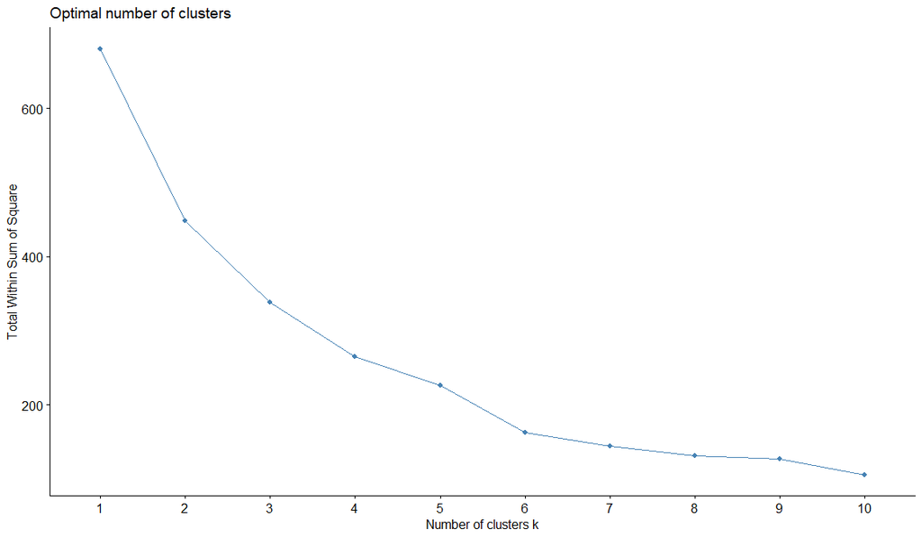

## Gráficos

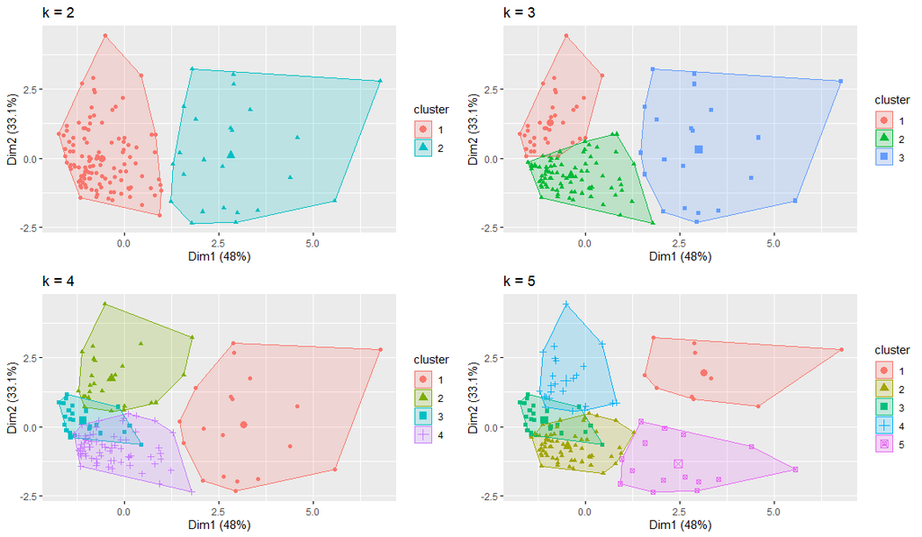

## Agrupar *cluster* e base

|  | estab_internacao | sim | nao | ign | total | taxa_sim | taxa_nao | saturacao.k5.cluster |
| --- | --- | --- | --- | --- | --- | --- | --- | --- |
| 5 | 2077574 CONJUNTO HOSPITALAR DO MANDAQUI SAO PAULO | 917 | 268 | 238 | 1423 | 0.6444132 | 0.1883345 | 5 |
| 7 | 2078015 HC DA FMUSP HOSPITAL DAS CLINICAS SAO PAULO | 1620 | 22 | 344 | 1986 | 0.8157100 | 0.0110775 | 5 |
| 10 | 2089238 HOSP ALVORADA | 1398 | 350 | 2 | 1750 | 0.7988571 | 0.2000000 | 5 |
| 20 | 2078589 HOSP MAT STA MARIA-CRUZ AZUL | 1172 | 309 | 179 | 1660 | 0.7060241 | 0.1861446 | 5 |
| 22 | 5420938 HOSP MUN CARMEN PRUDENTE | 1036 | 54 | 316 | 1406 | 0.7368421 | 0.0384068 | 5 |
| 30 | 9465464 HOSP MUN JOSANIAS CASTANHA BRAGA | 2056 | 70 | 82 | 2208 | 0.9311594 | 0.0317029 | 5 |
| 31 | 5718368 HOSP MUN M BOI MIRIM | 2123 | 452 | 19 | 2594 | 0.8184271 | 0.1742483 | 5 |
| 35 | 2080583 HOSP MUN TIDE SETUBAL | 2123 | 86 | 663 | 2872 | 0.7392061 | 0.0299443 | 5 |
| 72 | 2077426 HOSPITAL ESTADUAL DE VILA ALPINA ORG SOCIAL SECONCI SAO PAUL | 1227 | 5 | 401 | 1633 | 0.7513778 | 0.0030618 | 5 |
| 85 | 2058391 HOSPITAL ISRAELITA ALBERT EINSTEIN | 1597 | 7 | 36 | 1640 | 0.9737805 | 0.0042683 | 5 |
| 92 | 0161438 HOSPITAL MUNICIPAL GUARAPIRANGA | 2775 | 394 | 145 | 3314 | 0.8373567 | 0.1188896 | 5 |
| 104 | 7174721 HOSPITAL SANCTA MAGGIORE PARAISO | 1949 | 6 | 809 | 2764 | 0.7051375 | 0.0021708 | 5 |
| 116 | 2077485 HOSPITAL SAO PAULO HOSPITAL DE ENSINO DA UNIFESP SAO PAULO | 1111 | 216 | 28 | 1355 | 0.8199262 | 0.1594096 | 5 |
| 120 | 6668143 HOSPITAL VITORIA | 1165 | 7 | 28 | 1200 | 0.9708333 | 0.0058333 | 5 |
| 133 | 7479387 UPA III NOVA CAMPO LIMPO | 1786 | 40 | 588 | 2414 | 0.7398509 | 0.0165700 | 5 |
| 1 | 2077531 A C CAMARGO CANCER CENTER | 99 | 73 | 11 | 183 | 0.5409836 | 0.3989071 | 4 |
| 2 | 6430120 BP MIRANTE | 65 | 43 | 47 | 155 | 0.4193548 | 0.2774194 | 4 |
| 6 | 2078627 DAY HOSPITAL DE ERMELINO MATARAZZO | 117 | 87 | 2 | 206 | 0.5679612 | 0.4223301 | 4 |
| 11 | 2078481 HOSP AVICCENA | 259 | 356 | 9 | 624 | 0.4150641 | 0.5705128 | 4 |
| 12 | 2075962 HOSP DA STA CASA DE STO AMARO | 184 | 116 | 14 | 314 | 0.5859873 | 0.3694268 | 4 |
| 13 | 2088576 HOSP DE TRANSPLANT DO EST DE SP EURYCLIDES DE JESUS ZERBINI | 82 | 47 | 3 | 132 | 0.6212121 | 0.3560606 | 4 |
| 18 | 2078406 HOSP INDEPENDENCIA | 35 | 71 | 40 | 146 | 0.2397260 | 0.4863014 | 4 |
| 21 | 3045625 HOSP MAT VIDAS | 225 | 190 | 30 | 445 | 0.5056180 | 0.4269663 | 4 |
| 39 | 2084376 HOSP PAULISTANO | 81 | 105 | 13 | 199 | 0.4070352 | 0.5276382 | 4 |
| 42 | 5907594 HOSP SAO LUIZ ANALIA FRANCO | 318 | 120 | 77 | 515 | 0.6174757 | 0.2330097 | 4 |
| 50 | 2078457 HOSP STA VIRGINIA | 34 | 202 | 23 | 259 | 0.1312741 | 0.7799228 | 4 |
| 53 | 2084090 HOSPITAL BARTIRA | 87 | 104 | 2 | 193 | 0.4507772 | 0.5388601 | 4 |
| 57 | 2091801 HOSPITAL CENTRAL DE GUAIANASES | 62 | 118 | 33 | 213 | 0.2910798 | 0.5539906 | 4 |
| 67 | 6938876 HOSPITAL E MATERNIDADE INTERMEDICA ABC | 579 | 264 | 49 | 892 | 0.6491031 | 0.2959641 | 4 |
| 77 | 2091755 HOSPITAL GERAL DE VILA PENTEADO DR JOSE PANGELLA SAO PAULO | 610 | 278 | 71 | 959 | 0.6360792 | 0.2898853 | 4 |

[output cut: 107 more lines]

## Resumo do modelo

### Média Aritmética

| saturacao.k5$cluster | sim | nao | total | taxa_sim | taxa_nao |
| --- | --- | --- | --- | --- | --- |
| 1 | 1026.1000 | 679.80000 | 1878.8000 | 0.5475456 | 0.3738581 |
| 2 | 404.2812 | 44.92188 | 515.4062 | 0.7900963 | 0.0846187 |
| 3 | 182.2500 | 11.95833 | 523.4167 | 0.3661771 | 0.0260434 |
| 4 | 190.4167 | 134.37500 | 362.6667 | 0.5011672 | 0.3982656 |
| 5 | 1603.6667 | 152.40000 | 2014.6000 | 0.7992601 | 0.0780042 |

### Desvio padrão

[output not shown]

### Coeficiente de Variação

| saturacao.k5$cluster | sim | nao | total | taxa_sim | taxa_nao |
| --- | --- | --- | --- | --- | --- |
| 1 | 42.39470 | 34.89520 | 38.10343 | 22.71285 | 21.00369 |
| 2 | 63.09615 | 121.61083 | 61.99519 | 12.38996 | 84.73365 |
| 3 | 105.21629 | 175.15867 | 89.25762 | 45.29698 | 117.77222 |
| 4 | 85.72835 | 63.43914 | 69.73635 | 28.28843 | 32.55977 |
| 5 | 32.77784 | 105.95924 | 32.00253 | 12.27077 | 104.26088 |

# Base de dados de 2022

A base de dados para esta análise está disponível no aplicativo [TABNET](https://www.prefeitura.sp.gov.br/cidade/secretarias/saude/tabnet/index.php?p=296871) desenvolvido pelo DATASUS.

A Secretaria Municipal de Sáude de São Paulo disponibiliza o [TABNET](https://www.prefeitura.sp.gov.br/cidade/secretarias/saude/tabnet/index.php?p=296871) para o acesso às bases de dados de população e dos sistemas de informações do SUS.

## Carregando a base de dados

Esta análise traz o número de casos (**contéudo**) por estabelecimento de internação (**linha**) e por saturação de oxigênio (**coluna**) da página [COVID 19 Síndrome Respiratória Aguda Grave (SGAG)](http://tabnet.saude.prefeitura.sp.gov.br/cgi/tabcgi.exe?secretarias/saude/TABNET/RSRAG/sragh.def).

## Visão geral dos dados

```
## Rows: 69
## Columns: 7
## $ estab_internacao <chr> "2077531 A C CAMARGO CANCER CENTER", "2077574 CONJUNT…
## $ sim              <int> 40, 656, 306, 205, 24, 400, 55, 68, 563, 114, 59, 199…
## $ nao              <dbl> 95, 160, 2, 4, 0, 135, 104, 1, 195, 6, 39, 0, 6, 256,…
## $ ign              <dbl> 2, 135, 163, 25, 222, 1, 7, 187, 13, 7, 27, 13, 537, …
## $ total            <int> 137, 951, 471, 234, 246, 536, 166, 256, 771, 127, 125…
## $ taxa_sim         <dbl> 0.29197080, 0.68980021, 0.64968153, 0.87606838, 0.097…
## $ taxa_nao         <dbl> 0.693430657, 0.168243954, 0.004246285, 0.017094017, 0…
```

## Entendimento da base de dados

```
##   rows columns discrete_columns continuous_columns all_missing_columns
## 1   69       7                1                  6                   0
##   total_missing_values complete_rows total_observations memory_usage
## 1                    0            69                483        12336
```

[output not shown]

## Tipos de valores e ocorrência de valores ausentes.

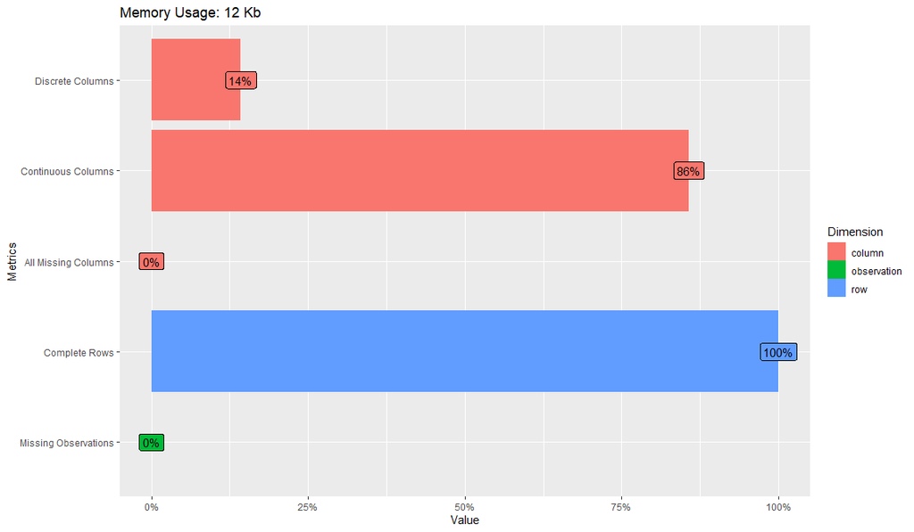

## Correlação entre as variáveis

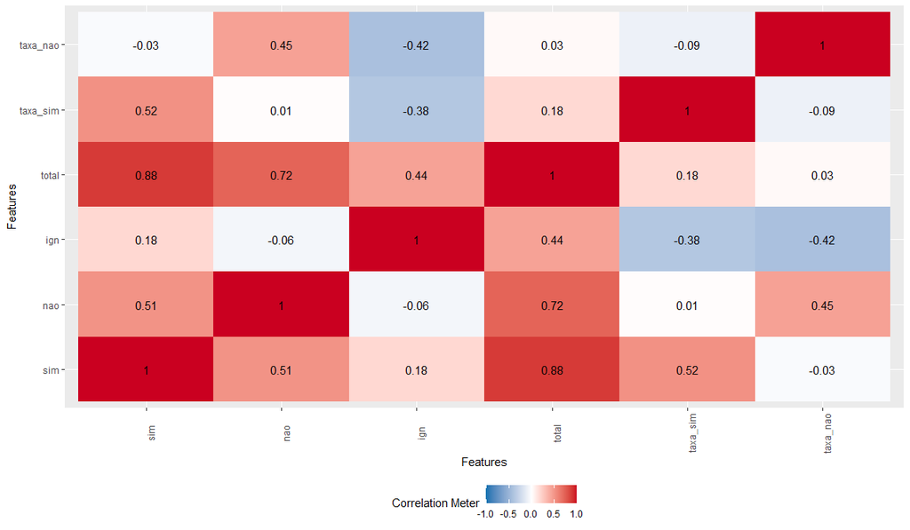

## Distribuição das variáveis quantitativas.

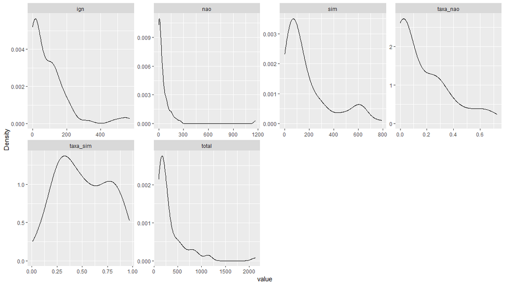

# Preparação dos dados

Para fins desta análise foram considerados todos os estabelecimentos de internação com um número de casos igual ou maior a 100 casos de internação/ano. Foram selecionados 69 estabelecimentos de internação com esta característica.

```
##   sim nao total   taxa_sim    taxa_nao
## 1  40  95   137 0.29197080 0.693430657
## 2 656 160   951 0.68980021 0.168243954
## 3 306   2   471 0.64968153 0.004246285
## 4 205   4   234 0.87606838 0.017094017
## 5  24   0   246 0.09756098 0.000000000
## 6 400 135   536 0.74626866 0.251865672
```

## Resumo sumário das variáveis

A próxima saída trás os valores de seis medidas (em ordem crescente):

- Menor valor (*Min*): o menor valor da variável registrada em algum estabelecimento de internação.
- Primeiro quartil Q<sub>1</sub> (*1st Qu*): 25% os estabelecimentos de internação registraram um valor da variável abaixo desse valor.
- Mediana Q<sub>2</sub> (*median*): 50% os estabelecimentos de internação registraram um valor da variável abaixo desse valor.
- Média (*mean*): média aritmética dos valores da variável registrada pelos estabelecimentos de internação.
- Terceiro quartil Q<sub>3</sub> (*3rd Qu*): 75% os estabelecimentos de internação registraram um valor da variável abaixo desse valor.
- Maior valor (*Max*): o maior valor da variável registrada em algum estabelecimento de internação.

```
##       sim             nao              total           taxa_sim
##  Min.   :  1.0   Min.   :   0.00   Min.   : 100.0   Min.   :0.007634
##  1st Qu.: 47.0   1st Qu.:   1.00   1st Qu.: 137.0   1st Qu.:0.287879
##  Median :107.0   Median :  27.00   Median : 227.0   Median :0.472000
##  Mean   :189.8   Mean   :  60.36   Mean   : 343.2   Mean   :0.508384
##  3rd Qu.:264.0   3rd Qu.:  70.00   3rd Qu.: 409.0   3rd Qu.:0.742788
##  Max.   :789.0   Max.   :1168.00   Max.   :2128.0   Max.   :0.966216
##     taxa_nao
##  Min.   :0.00000
##  1st Qu.:0.00519
##  Median :0.08961
##  Mean   :0.17034
##  3rd Qu.:0.27869
##  Max.   :0.72477
```

À guisa de exemplo, considere a *feature* **taxa de sim**:

Observe que 25% dos estabelecimentos de internação registraram uma taxa de saturação por SRAG igual ou maior a 74,27%.

Esta informação pode ser visualizada no seguinte *boxplot*.

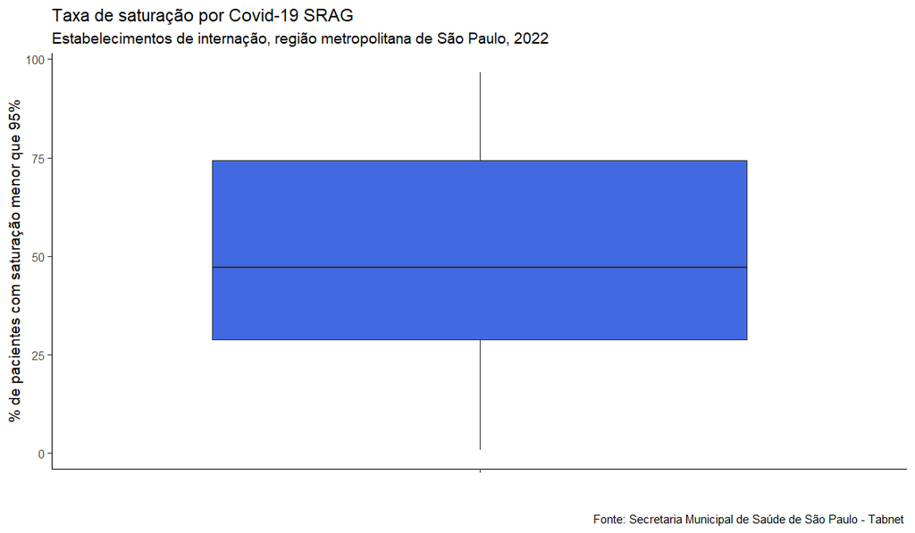

## Padronização dos dados

A utilização de variáveis com medidas e ou escalas diferentes podem distorcer a estrutura do *cluster*. Variáveis com maior dispersão têm maior peso para o cálculo das medidas de distância do que as demais.

A padronização dos dados faz com que seja atribuído o mesmo peso para cada variável. Neste estudo foi utilizada a transformação de cada variável em escore padrão (*Z score*). O método Z score padroniza cada variável de modo a apresentar uma média zero(0) e desvio padrão um (1):

$$Z = \frac{(x - média)}{desvio \ padrão}$$

```
##              sim        nao      total   taxa_sim    taxa_nao
## [1,] -0.75374084  0.2354148 -0.6168145 -0.8447418  2.60399267
## [2,]  2.34611410  0.6771869  1.8175896  0.7081351 -0.01045198
## [3,]  0.58483288 -0.3966591  0.3820687  0.5515368 -0.82685276
## [4,]  0.07657744 -0.3830661 -0.3267197  1.4352093 -0.76289515
## [5,] -0.83425656 -0.4102521 -0.2908317 -1.6035960 -0.84799129
## [6,]  1.05786269  0.5072745  0.5764622  0.9285525  0.40582732
```

# Modelagem estatística - Método *K-means*

O método *k-means* é um procedimento não hierárquico para agrupar indivíduos, cujo número inicial de *clusters* é definido pelo pesquisador.

O algoritmo para determinar a alocação das observações em cada conglomerado é denominado *nearest centroid sorting*. O *K-means* usa a distância euclidiana como critério de distância para formar os grupos.

## Determinação do número de *clusters*

O método *k-means* é um procedimento não hierárquico para agrupar indivíduos, cujo número inicial de *clusters* é definido pelo pesquisador.

A análise visual a partir de um gráfico de linhas de duas dimensões: os *K Clusters* (*Number of clusters k*) e a Soma dos Quadrados dos Erros de Predição (*Total Within Sum of Square - SSE*) sugere um número inicial de *clusters* para ser usado. O SSE resulta na variância e desvio padrão (inércia) dos dados de nossa base. Desta forma pode-se visualizar o valor de quão próximo os dados estão uns dos outros. Quanto menor for o número de *clusters*, maior será o valor dessa inércia.

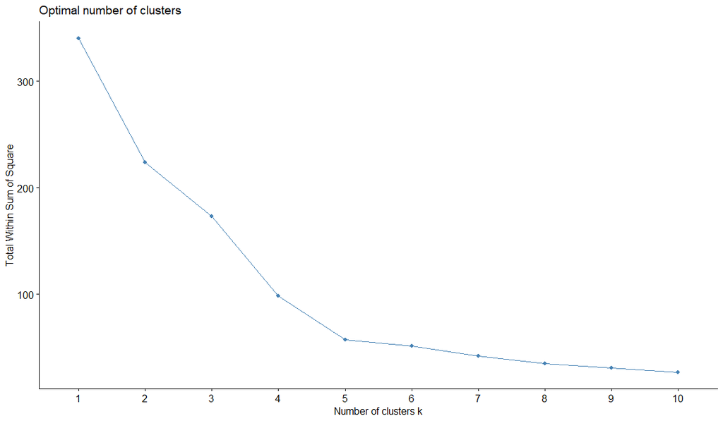

No gráfico acima, nota-se que a partir do quinto *cluster*, o valor do SSE não tem mais grandes variações. Aumentar o número de *clusters* indica que esta variação se tornaria cada vez menor. Sendo assim, a quantidade de cinco *clusters* parece ser um número bem interessante para se aplicar nesse conjunto de dados.

## Gráficos

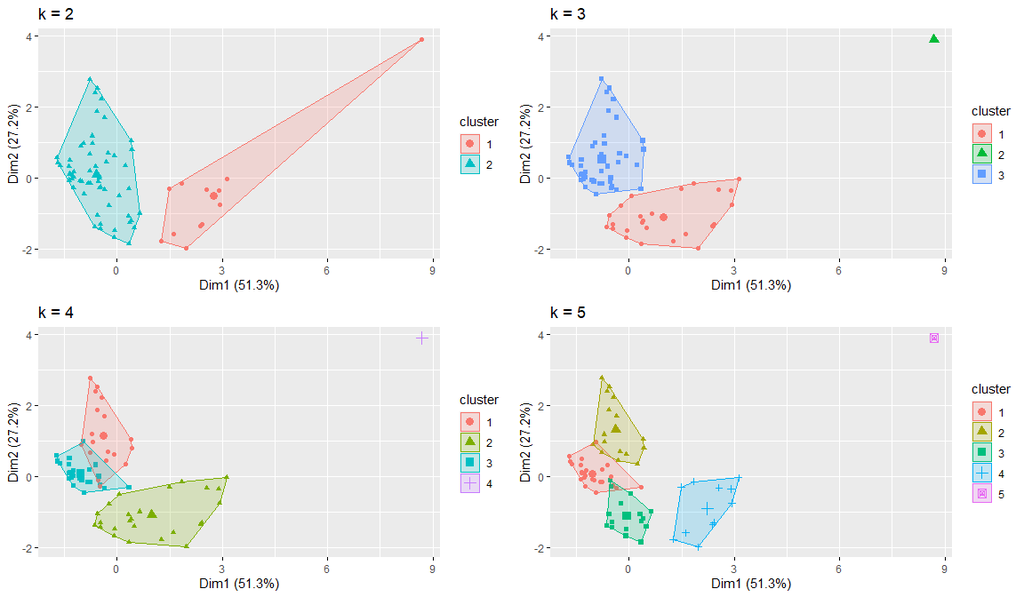